# Simulating and Understanding the SpecParam (FOOOF) Knee Parameter

An Interactive Guide to Aperiodic Component Modeling

Author

Daniel Borek

## 1. Theoretical Framework

The power spectrum of electrophysiological recordings (e.g., EEG, iEEG, LFP) contains two major components: **periodic activity** (oscillatory peaks) and **aperiodic activity** (the 1/f-like background).

The `specparam` (formerly `FOOOF`) algorithm parameterizes the aperiodic component in log-log space. In its general **Knee mode**, the aperiodic power spectrum $L(f)$ is modeled as:

$$L(f) = b - \log_{10}(k + f^{\chi})$$

where: - $L(f)$ is the log-power at frequency $f$. - $b$ is the **offset**, related to the overall vertical position of the spectrum. - $k$ is the **knee parameter**, representing the bend/transition point in the spectrum. - $\chi$ is the **exponent**, representing the slope of the power spectrum at high frequencies.

### 1.1 The Role of the Knee Parameter ($k$)

To understand the mathematical behavior of the knee parameter, we can examine its limits at low and high frequencies:

#### Low Frequency Plateau ($f \ll k^{1/\chi}$)

When the frequency $f$ is small enough such that $f^{\chi}$ is much smaller than the knee parameter $k$, the $f^{\chi}$ term becomes negligible:

$$L(f) \approx b - \log_{10}(k)$$

This yields a flat, horizontal **plateau** of height $b - \log_{10}(k)$. The height of the plateau is determined jointly by the offset $b$ and the knee parameter $k$.

#### High Frequency Power-Law ($f \gg k^{1/\chi}$)

When the frequency $f$ is large such that $f^{\chi}$ is much larger than $k$, the knee parameter $k$ becomes negligible:

$$L(f) \approx b - \log_{10}(f^{\chi}) = b - \chi \log_{10}(f)$$

In log-log space, this is a straight line with a constant negative slope equal to $-\chi$.

### 1.2 The Knee Frequency ($f_k$) and Time Constant ($\tau$)

The **Knee Frequency** ($f_k$ in Hz) marks the transition point (the “bend”) between the low-frequency plateau and the high-frequency slope. This is the frequency where the two terms inside the logarithm are equal:

$$f_k^{\chi} = k \implies f_k = k^{1/\chi}$$

At this exact frequency, the log-power is:

$$L(f_k) = b - \log_{10}(k + k) = b - \log_{10}(2k) = \left(b - \log_{10}(k)\right) - \log_{10}(2) \approx \text{Plateau Height} - 0.301$$

This means $f_k$ is the frequency at which the power drops by $\log_{10}(2) \approx 0.3$ log units (or 3 dB) below the low-frequency plateau. It is mathematically analogous to the **cut-off frequency** of a first-order low-pass filter!

#### Relationship to Time Constants ($\tau$)

Under physical models of neural activity (such as shot-noise models or membrane potential dynamics), the knee frequency corresponds to a characteristic neural relaxation timescale or **time constant** ($\tau$):

$$\tau = \frac{1}{2\pi f_k} = \frac{1}{2\pi k^{1/\chi}}$$

A higher knee parameter $k$ corresponds to a higher knee frequency $f_k$, which translates to a shorter time constant $\tau$ (faster decay of neural correlations).

## 2. Python Setup and Imports

Let’s initialize our Python environment and load the necessary libraries.

## 3. Mathematical Simulation of the Aperiodic Component

Let’s define a function that implements the SpecParam knee equation so we can compute and plot the spectra manually.

### 3.1 Parameter Sweep: Varying the Knee Parameter ($k$)

Here, we keep the offset ($b=3.0$) and exponent ($\chi=1.5$) constant, and vary $k$ from $2.0$ to $50.0$.

Notice how: 1. A larger $k$ shifts the low-frequency plateau downwards. 2. A larger $k$ pushes the knee (bend) frequency further to the right. 3. At high frequencies, all curves converge asymptotically to the same slope ($-\chi = -1.5$).

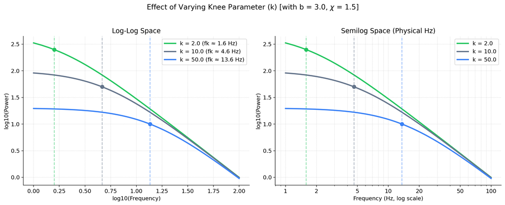

### 3.2 Parameter Sweep: Varying the Exponent ($\chi$)

Now we keep the offset ($b=3.0$) and the knee parameter ($k=10.0$) constant, and vary $\chi$ from $1.0$ to $2.0$.

Notice how: 1. At low frequencies, all curves start at the *exact same plateau height* ($b - \log_{10}(k) = 3.0 - \log_{10}(10) = 2.0$). 2. As the exponent increases, the high-frequency slope becomes steeper. 3. The knee frequency ($f_k = k^{1/\chi}$) shifts to the left as $\chi$ increases (since $10^{1.0} = 10$ Hz, but $10^{1/2} = 3.16$ Hz).

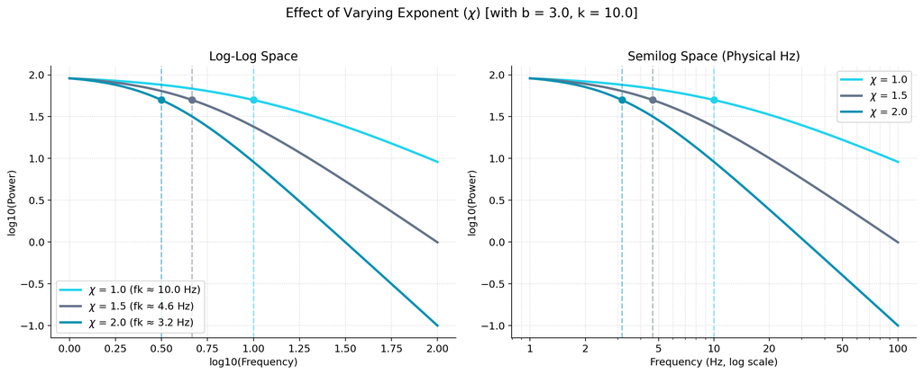

## 4. Unified Interactive Simulation and Fitting Dashboard

In a live Jupyter notebook or when running this document locally in VS Code, you can execute the following cell to get a comprehensive interactive dashboard.

This dashboard combines the **generative simulation** (parameters $b$, $k$, and $\chi$) with **dynamic model fitting** using `specparam` over a configurable frequency **Fit Range**.

Drag the sliders to see: 1. How the theoretical knee transitions dynamically (crimson markers). 2. How simulated noisy power spectral data (incorporating a simulated 10 Hz alpha peak) responds to ground-truth changes. 3. How fitting a **Knee model** (teal curve) vs. a **Fixed model** (orange dashed curve) over different frequency ranges distorts or recovers the true parameters (summarized in the tabular comparison below the plots).

## 5. Why You Can’t Ignore the Knee: Fitting Bias Demonstration

A very common methodological pitfall in neural spectral analysis is fitting a **Fixed model** (straight line in log-log space) to a spectrum that actually possesses a **Knee**.

Let’s simulate this scenario and fit both models using `specparam` to see the resulting parameter distortion.

### 5.1 Simulate a Power Spectrum with a Knee and Noise

We’ll simulate a true power spectrum with $b=3.0$, $k=15.0$, $\chi=2.0$ (representing standard cortical membrane dynamics) and add gaussian noise.

### 5.2 Fit Both Models Using SpecParam

We will use the standard `SpectralModel` object from `specparam` to fit the spectrum in: 1. **Knee Mode** (`aperiodic_mode='knee'`) 2. **Fixed Mode** (`aperiodic_mode='fixed'`)

### 5.3 Compare the Fit Parameters and Plots

Let’s inspect the results:

```
============================================================
Parameter                 | True Value | Knee Fit   | Fixed Fit
------------------------------------------------------------
Offset (b)                | 3.00       | 2.96       | 2.61
Knee Parameter (k)        | 15.00      | 12.66      | N/A
Exponent (chi)            | 2.00       | 1.99       | 1.77
Goodness of fit (R^2)     | N/A        | 0.999      | 0.981
============================================================
```

Let’s visualize this overlay.

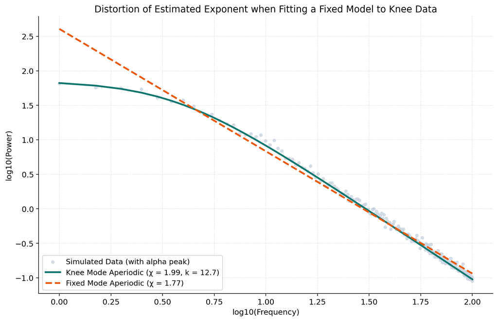

## 5.4 Interactive Fitting Range Analysis

This dynamic analysis is now fully integrated into the **Unified Interactive Simulation and Fitting Dashboard** in Section 4.

You can use the **Fit Range (Hz)** slider in that unified dashboard to explore how limiting the frequency range (e.g., to 30 - 100 Hz) changes the fits. In the unified dashboard, you can simultaneously manipulate the ground-truth simulation parameters ($b, k, \chi$) and the fitting boundaries to see their combined effects in real time!

## 6. Summary of Key Insights

When analyzing biological power spectra: 1. **Biological Meaning**: The transition represented by the knee frequency ($f_k$) is not just a fitting parameter, it corresponds directly to a **neural timescale (time constant $\tau$)**. Shifting this transition marks changes in how long synaptic and circuit inputs are integrated. 2. **Methodological Rigor**: If your power spectrum spans lower frequencies (e.g., $< 20$ Hz) and shows any sign of bending, **always use the Knee mode** in SpecParam. As demonstrated above, fitting a Fixed model will lead to a **downward bias** in the calculated aperiodic exponent, which might obscure true biological differences or create artificial ones!

### 🌐 Shareable Serverless Python Shiny Web Dashboard

We have compiled this interactive analysis as a standalone, serverless web application powered by **Shiny for Python running in WebAssembly (Shinylive)**.

This beautiful dashboard is styled with a modern, publication-grade Bootstrap theme (`minty`) and uses **official Python packages (SpecParam, SciPy, NumPy, and Matplotlib) under the hood**! It compiles your exact Python reactives and fitting routines into a static, client-side package. Once opened, the browser’s Pyodide engine downloads and caches these wheels. **Subsequent visits will load instantly (<400ms)** with complete offline support.

Once pushed to GitHub and hosted on **GitHub Pages**, anyone can open the dashboard directly in their browser (e.g., via a **QR code** on your poster, slides, or paper) and interact with your actual Python mathematical fits in real-time!

- The compiled application entrypoint is located in docs/index.html and defined in dashboard/app.py.
- See docs/README.md for step-by-step instructions on compiling local changes, deploying to GitHub Pages, and generating high-quality vector QR codes.